# MacroSheds Solute Trends

Nick Gubbins

# Scope

Provide a high level analysis of trends in riverine solute concentrations throughout the MS database.

# Calculate Trends

After running load_data, you can run the following functions to generate the trends data set. The function will apply to all the sites you have downloaded in your MS data directory.

```r
#analyze_trend(target_solute = 'SO4_S', ms_root = here('ms_data'))
#analyze_trend(target_solute = 'pH', ms_root = here('ms_data'))
#analyze_trend(target_solute = 'DOC', ms_root = here('ms_data'))
```

The ‘analyze_trend’ function calculates annual and seasonal trends for sites that meet the required data cutoffs. The current cutoffs are

- Site is in the CONUS
- Data across at least 10 water years
- Data across at least 3 seasons
- There are at least 3 samples in 10 or more seasons

The function then applies 5 linear models (annual + four seasons) across mean, low (5% percentile value), and high concentrations for each time period. The function uses USGS water years for annual aggregation and simple, three month periods for each season.

# Summarizing trends

```r
trends <- read_csv(here('trends','SO4_S_trends.csv'), show_col_types = FALSE) %>%
    rbind(.,read_csv(here('trends','DOC_trends.csv'), show_col_types = FALSE)) %>%
    rbind(.,read_csv(here('trends','pH_trends.csv'), show_col_types = FALSE))

site_data <- ms_load_sites()

sf_trends <- trends %>%
    left_join(., site_data, by = c('site' = 'site_code', 'domain')) %>%
    filter(!is.na(longitude),
           !is.na(latitude)) %>%
    st_as_sf(., coords = c('longitude', 'latitude'), crs = 4326)

sf_trends %>%
    select(domain_fullname, site, n_ann, geometry) %>%
    distinct() %>%
    mapview(.,
            zcol = 'n_ann',
            legend = T,
            label = 'domain_fullname',
            layer.name = 'Years of data')
```

[interactive chart not shown]

The map above shows good national coverage. Sites are colored by years of data available.

# Annual DOC Trends

## Mean

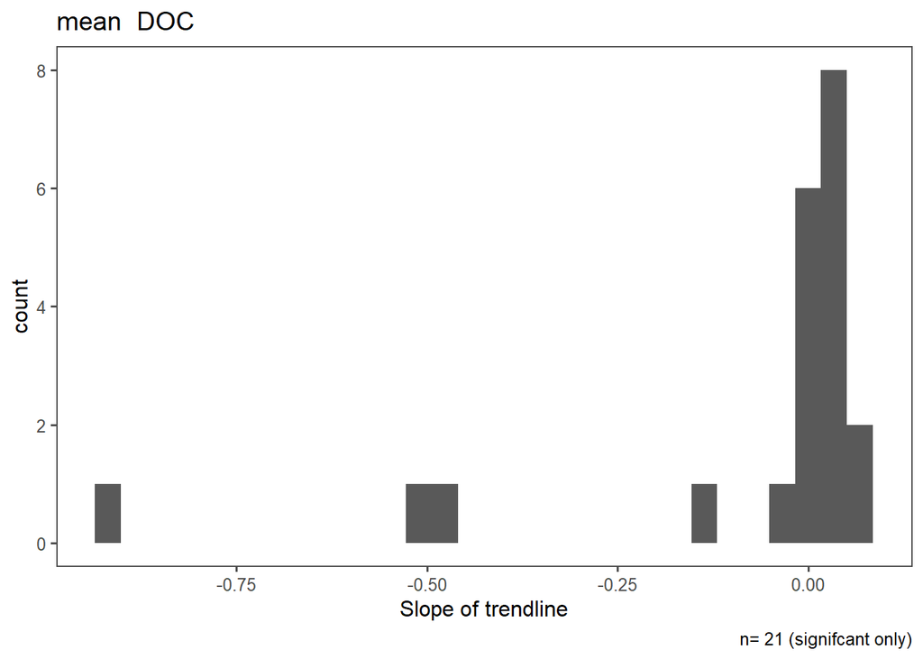

[interactive chart not shown]

## High

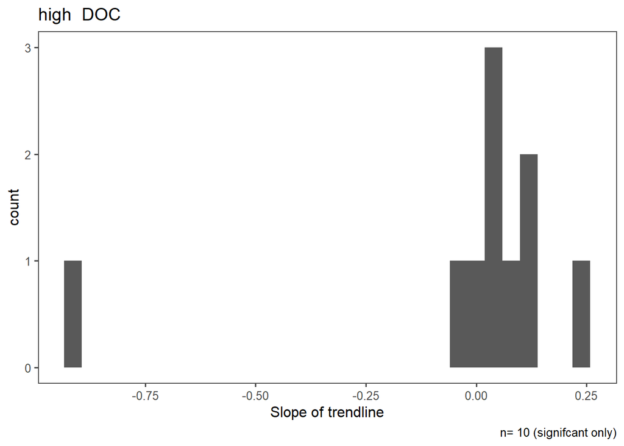

[interactive chart not shown]

## Low

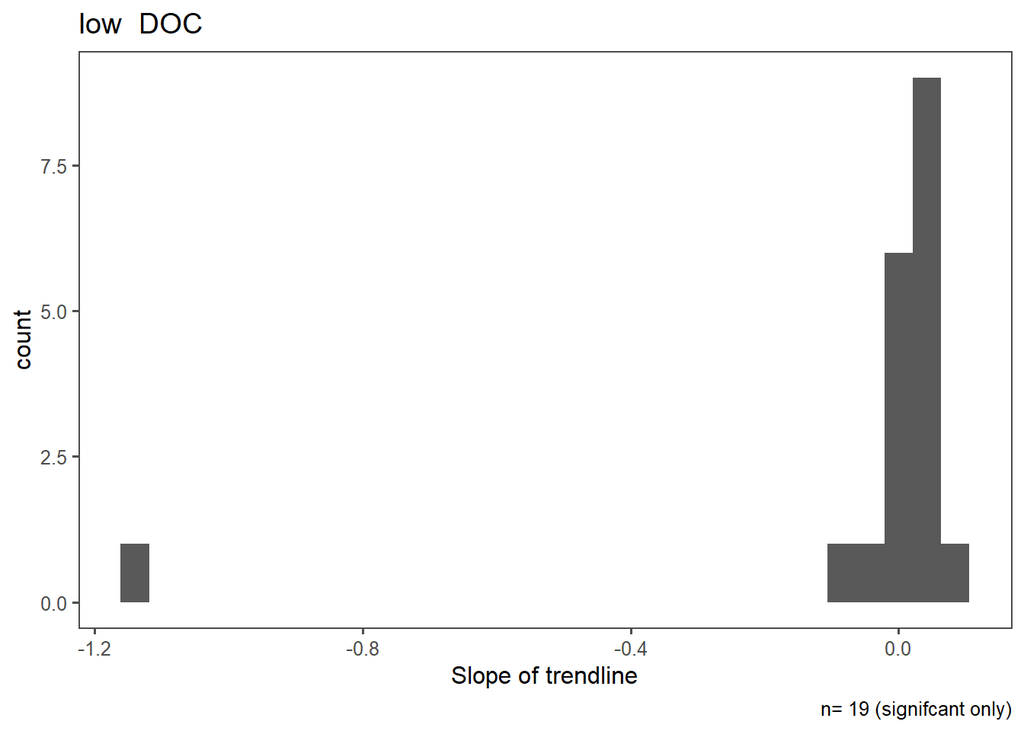

[interactive chart not shown]

# Seasonal DOC Trends

## Mean

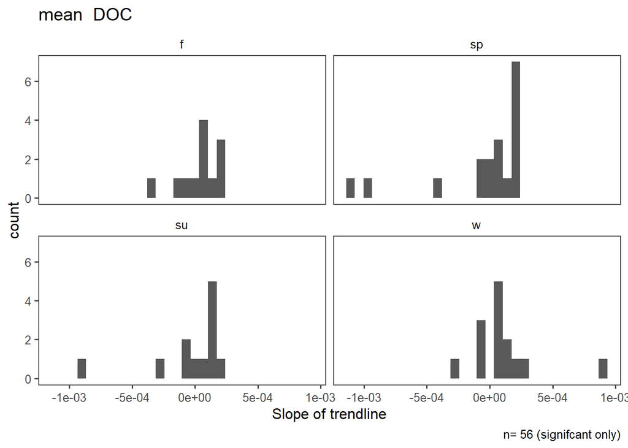

[interactive chart not shown]

## High

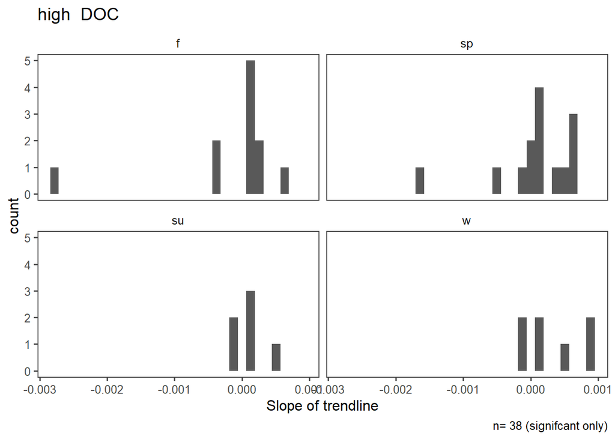

[interactive chart not shown]

## Low

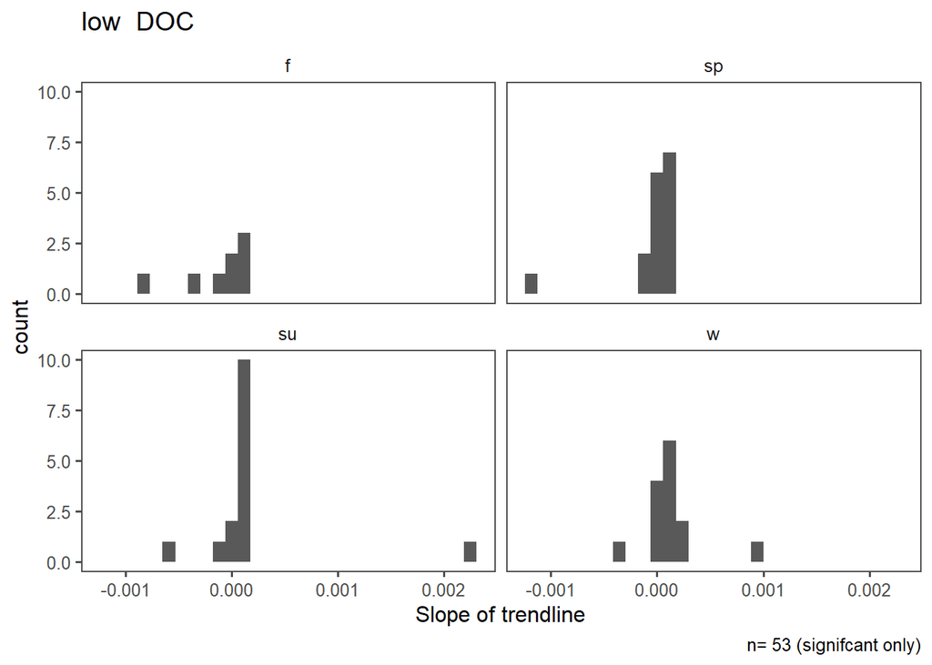

[interactive chart not shown]

# Annual pH Trends

## Mean

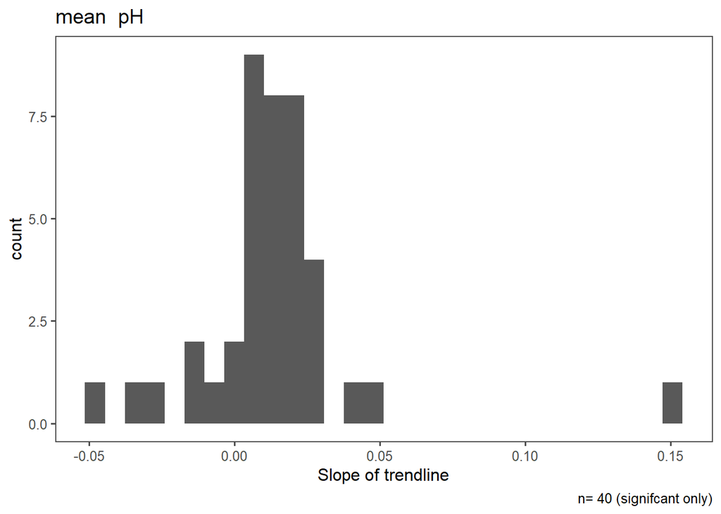

[interactive chart not shown]

## High

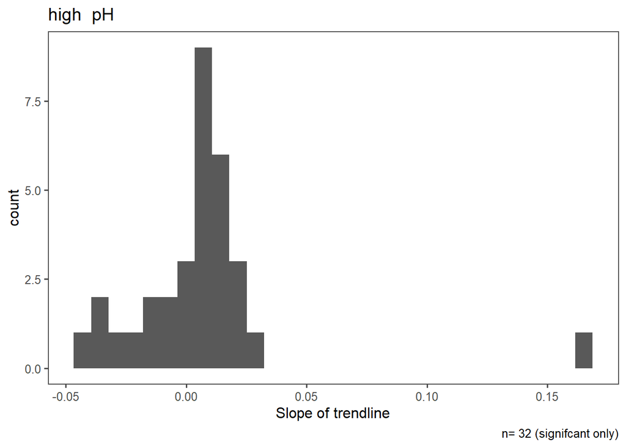

[interactive chart not shown]

## Low

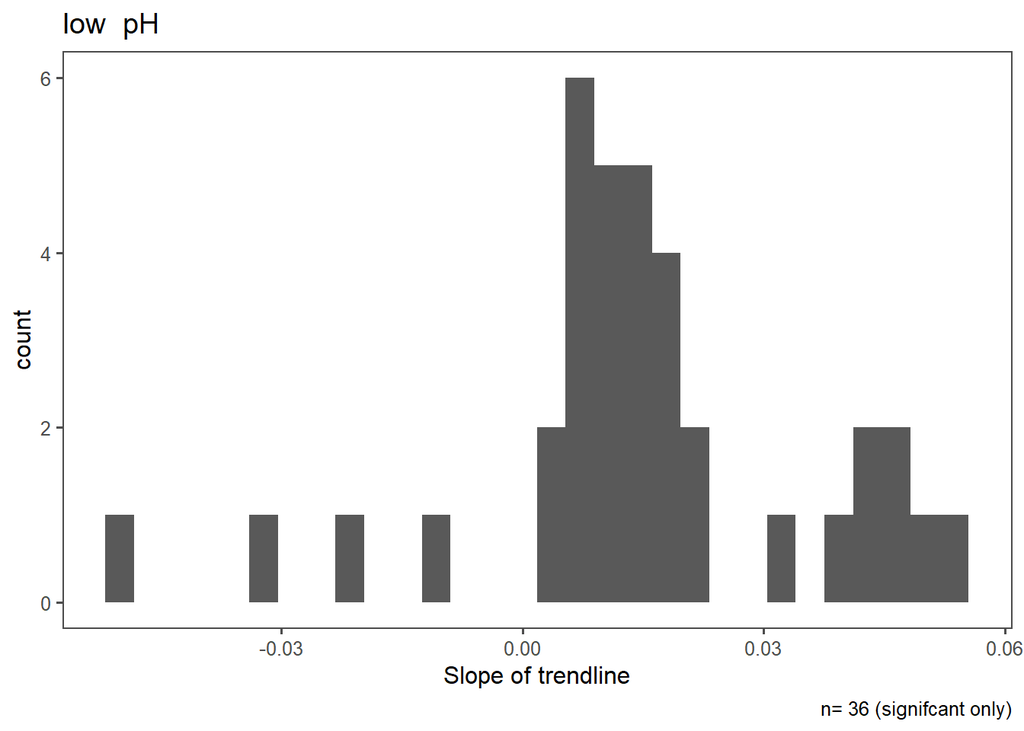

[interactive chart not shown]

# Seasonal pH Trends

## Mean

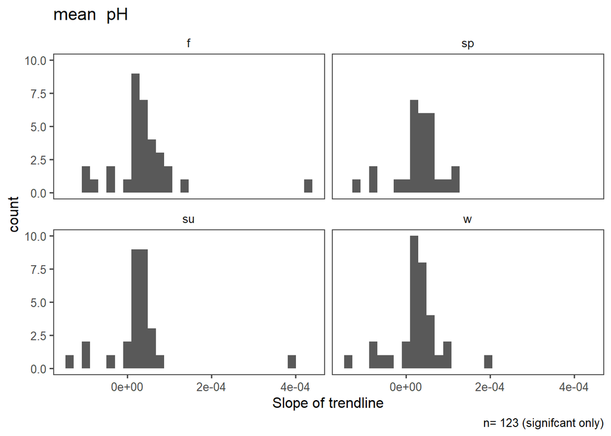

[interactive chart not shown]

## High

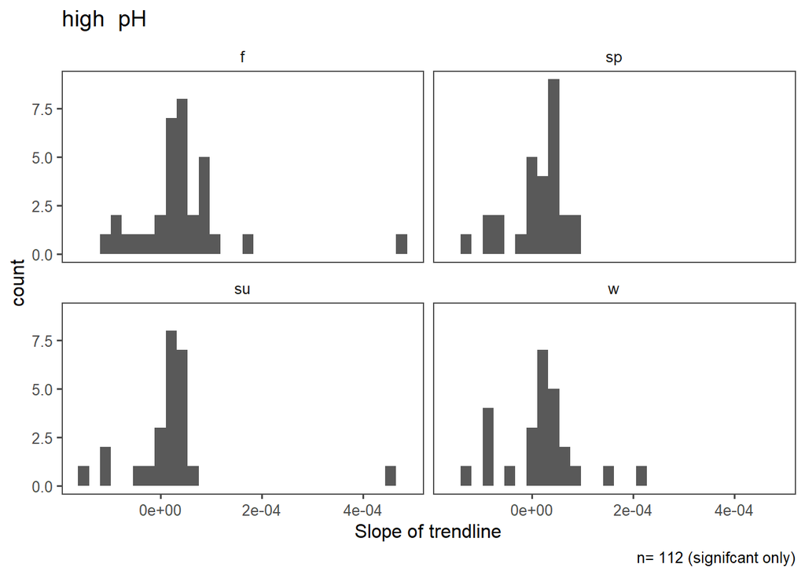

[interactive chart not shown]

## Low

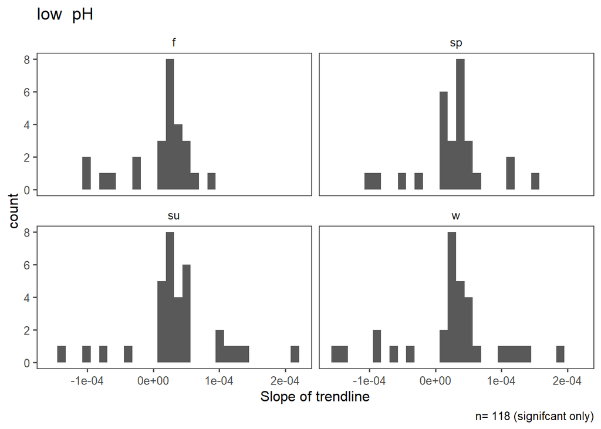

[interactive chart not shown]

# Annual SO4_S Trends

## Mean

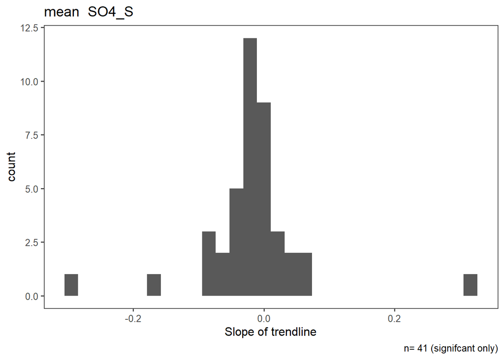

[interactive chart not shown]

## High

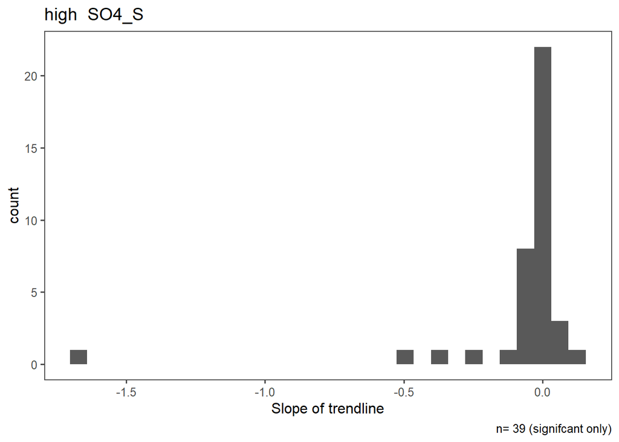

[interactive chart not shown]

## Low

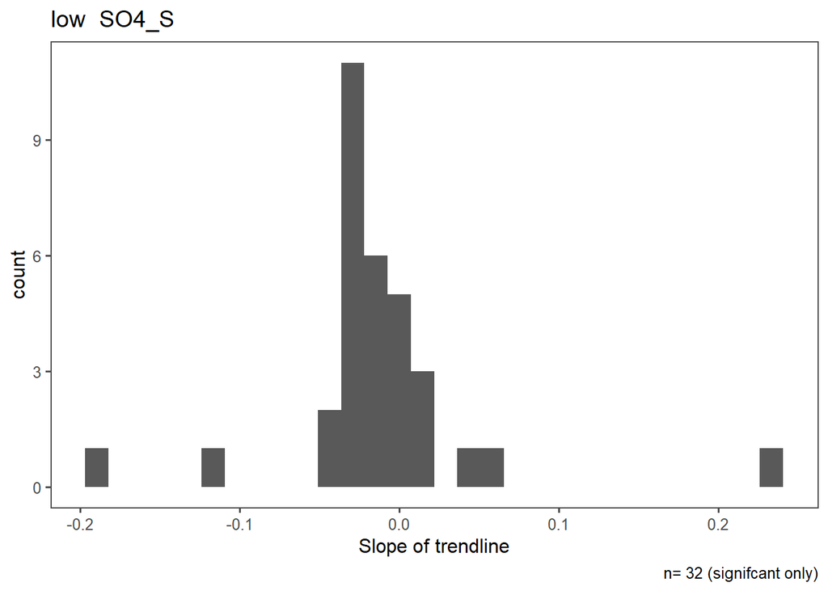

[interactive chart not shown]

# Seasonal SO4_S Trends

## Mean

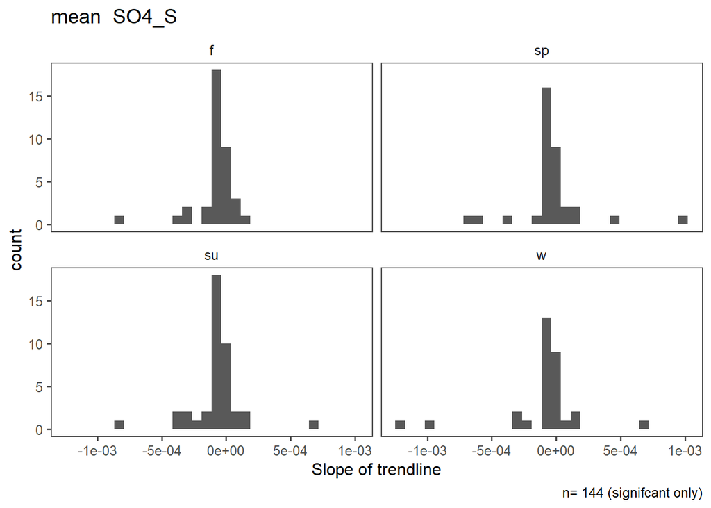

[interactive chart not shown]

## High

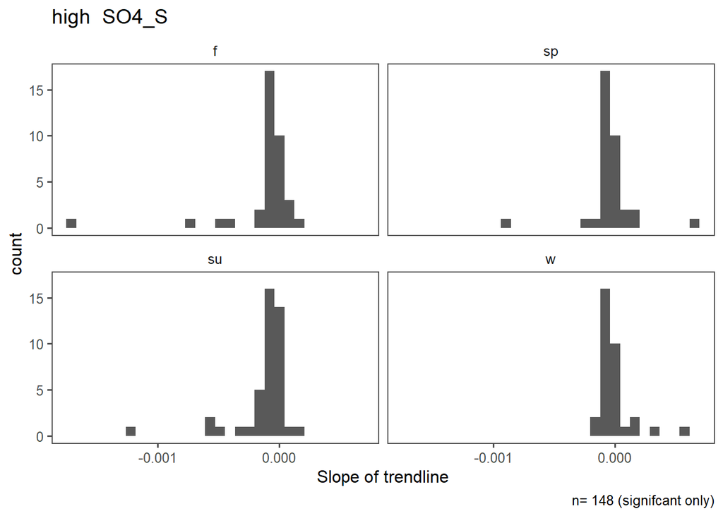

[interactive chart not shown]

## Low

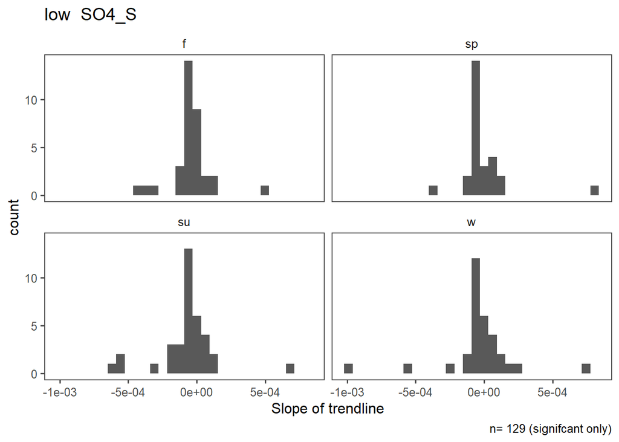

[interactive chart not shown]